# Taller 2 — Usar e interpretar PCA en datos ómicos

Unidad 3 · Exploración, calidad de muestras y perfiles clínicos

Alex Di Genova

13-11-2026

# 1 Caso y objetivo

Recibimos expresión de **600 genes en 150 pacientes**, junto con lote de procesamiento, edad, sexo y respuesta clínica. Queremos reconocer las principales diferencias entre muestras, investigar su origen y describir grupos de pacientes.

Los datos son **simulados**, ya transformados a una escala continua comparable. No representan pacientes reales ni son conteos crudos de RNA-seq. La generación de datos está disponible en `scripts/generar_datos_clase2.R`; para realizar las actividades basta con cargar los archivos entregados.

Trabajaremos con PCA como herramienta **no supervisada**: no incluimos la respuesta clínica al calcular los componentes. Después usaremos la metadata para interpretar lo que aparece. Un análisis supervisado, en cambio, usaría una respuesta conocida para aprender a predecirla en nuevos pacientes.

**Al finalizar podrán:** ejecutar PCA, leer sus gráficos, comparar ejes, interpretar loadings, investigar lote y outliers, y justificar una agrupación sin confundirla con un diagnóstico.

## 1.1 Preparación

Ejecuten los bloques en orden. Requiere R ≥ 4.1. Si falta un paquete, instálenlo con la instrucción indicada en el error. Para ocultar las orientaciones finales: `rmarkdown::render("taller_clase2.Rmd", params = list(mostrar_soluciones = FALSE))`.

```r
paquetes <- c("rmarkdown", "knitr", "ggplot2", "dplyr", "tidyr", "broom", "cluster")
faltantes <- paquetes[!vapply(paquetes, requireNamespace, logical(1), quietly = TRUE)]
if (length(faltantes)) {
  stop("Instale primero: install.packages(c(",
       paste(sprintf('"%s"', faltantes), collapse = ", "), "))")
}
stopifnot(getRversion() >= "4.1.0")
library(ggplot2)
library(dplyr)
library(tidyr)
library(broom)
knitr::opts_chunk$set(
  echo = TRUE, warning = TRUE, message = FALSE, error = FALSE,
  fig.path = "figuras/clase2-", fig.width = 7.4, fig.height = 4.6,
  dpi = 170, out.width = "95%", cache = FALSE
)
theme_set(theme_minimal(base_size = 13) +
  theme(plot.title = element_text(face = "bold", colour = "#17324D"),
        panel.grid.minor = element_blank(), legend.position = "bottom"))
paleta <- c("#2A7F7B", "#D95F59", "#D58B31", "#506273")
stopifnot(length(params$n_pcs) == 1, is.finite(params$n_pcs),
          params$n_pcs >= 2, params$n_pcs <= 10,
          params$n_pcs == as.integer(params$n_pcs))
```

# 2 Actividad 1 — Cargar y reconocer los datos

Cada fila de expresión corresponde a una muestra. La primera columna es el ID; las restantes son genes. En otros archivos ómicos puede aparecer la orientación inversa: genes en filas. Comprueben siempre qué espera la función de PCA.

```r
archivos <- c("datos/clase2_expresion.csv", "datos/clase2_metadata.csv",
              "datos/clase2_subtipos_simulados.csv")
if (!all(file.exists(archivos))) {
  stop("Faltan datos. Desde la carpeta class ejecute: ",
       "Rscript scripts/generar_datos_clase2.R")
}
expresion <- read.csv(archivos[1], row.names = 1, check.names = FALSE)
expr <- as.matrix(expresion)
metadata <- read.csv(archivos[2], stringsAsFactors = FALSE) |>
  mutate(lote = factor(lote), sexo = factor(sexo),
         respuesta = factor(respuesta, levels = c("No", "Sí")))
dim(expr)
```

```
## [1] 150 600
```

```r
head(metadata)
```

|  | id | lote | edad | sexo | respuesta |
| --- | --- | --- | --- | --- | --- |
| 1 | P001 | L1 | 51 | Mujer | Sí |
| 2 | P002 | L1 | 74 | Hombre | Sí |
| 3 | P003 | L2 | 42 | Mujer | No |
| 4 | P004 | L1 | 68 | Mujer | No |
| 5 | P005 | L2 | 48 | Hombre | No |
| 6 | P006 | L2 | 72 | Mujer | Sí |

| Campo | Interpretación | Uso |
| --- | --- | --- |
| ID | Identificador de muestra | Unir archivos |
| GEN0001…GEN0600 | Expresión transformada | Entrada del PCA |
| lote | L1 / L2 | Revisar diferencias técnicas |
| edad, sexo | Metadata de pacientes | Describir perfiles |
| respuesta | No / Sí | Interpretar después del PCA |
| Archivo de subtipos | Verdad de simulación | Auditoría al final |

```r
stopifnot(!anyDuplicated(metadata$id), !anyDuplicated(rownames(expr)),
          setequal(metadata$id, rownames(expr)), is.numeric(expr),
          all(is.finite(expr)))
# Alinear los archivos por ID, no por el orden en que fueron guardados.
metadata <- metadata[match(rownames(expr), metadata$id), ]
stopifnot(identical(metadata$id, rownames(expr)))
qc <- metadata |>
  mutate(media = rowMeans(expr), sd = apply(expr, 1, sd),
         prop_extremos = rowMeans(abs(expr) > 3))
qc |> arrange(desc(prop_extremos)) |> head(6)
```

|  | id | lote | edad | sexo | respuesta | media | sd | prop_extremos |
| --- | --- | --- | --- | --- | --- | --- | --- | --- |
| 1 | P007 | L1 | 46 | Mujer | Sí | 0.7026729 | 1.5213481 | 0.120000000 |
| 2 | P030 | L2 | 40 | Hombre | No | 0.4800949 | 0.9572931 | 0.008333333 |
| 3 | P115 | L2 | 63 | Mujer | No | 0.4278196 | 0.9781154 | 0.008333333 |
| 4 | P006 | L2 | 72 | Mujer | Sí | 0.4421408 | 0.9549134 | 0.006666667 |
| 5 | P027 | L2 | 34 | Hombre | Sí | 0.3848369 | 0.9704599 | 0.006666667 |
| 6 | P118 | L2 | 41 | Mujer | Sí | 0.4455835 | 0.9275973 | 0.006666667 |

```r
table(metadata$lote)
```

```
##
## L1 L2
## 75 75
```

**Registren:** número de pacientes y genes, significado de cada fila y dos comprobaciones de calidad. Si hay faltantes o IDs discordantes, investiguen su origen antes de continuar; el código se detiene para evitar decisiones implícitas.

# 3 Actividad 1

plot por patience simple

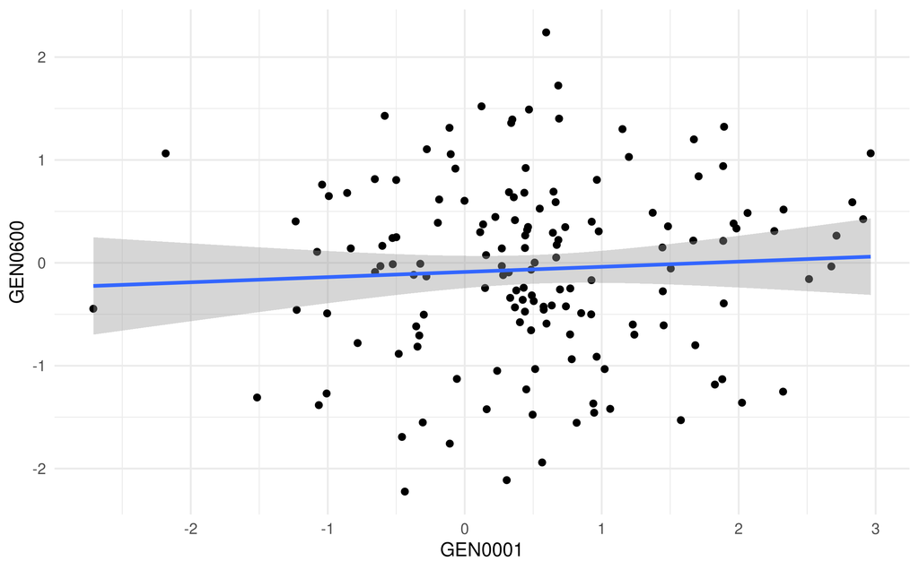

```r
#
expresion %>% select(GEN0001, GEN0600) %>% ggplot(aes(x=GEN0001,y=GEN0600)) + geom_point() + geom_smooth(method="lm") + theme_minimal()
```

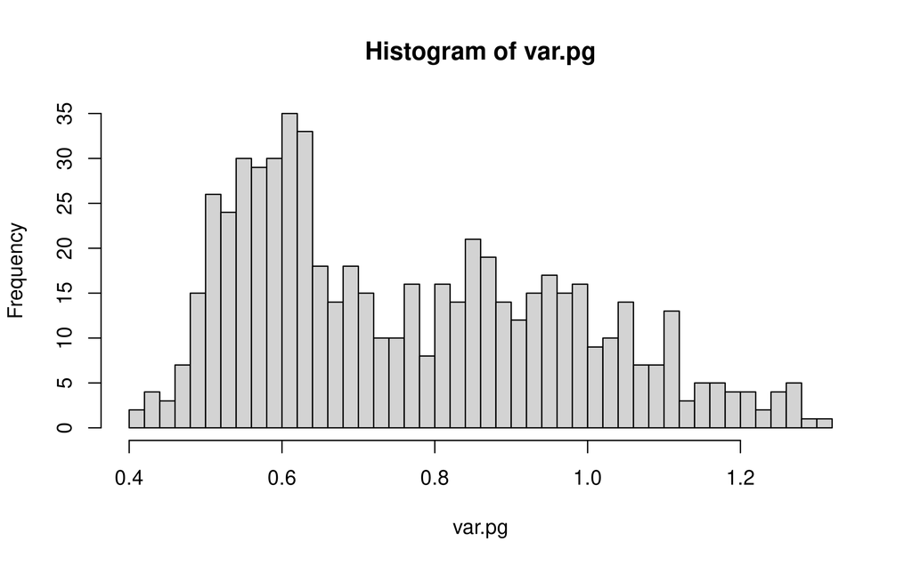

```r
# determinar sd,var, mean, median etc por gen en el dataset
var.pg=apply(t(expresion),1, var, na.rm=TRUE)


hist(var.pg,nclass=50)
```

# 4 Actividad 2 — Ejecutar PCA y leer la varianza explicada

Eliminamos genes constantes y ejecutamos PCA. **Centrar** permite comparar cambios respecto del promedio de cada gen; **escalar** pone esos cambios en unidades comparables. Con otras plataformas esta elección debe revisarse.

```r
# eliminando genes por varianza baja
var_gen <- apply(expr, 2, var)
expr_f <- expr[, is.finite(var_gen) & var_gen > 0.1]
# prcomp ejecuta PCA
pca <- prcomp(expr_f, center = TRUE, scale. = TRUE)
# coordenadas de las muestras en el PC
#pca$x
# coefeciences o loadings de los genes en el PC
#pca$rotation

var_exp <- 100 * pca$sdev^2 / sum(pca$sdev^2)
resumen_pcs <- tibble(
  PC = seq_along(var_exp), porcentaje = var_exp,
  acumulado = cumsum(var_exp)
)
head(resumen_pcs, 10)
```

| PC | porcentaje | acumulado |
| --- | --- | --- |
| 1 | 11.228529 | 11.22853 |
| 2 | 4.850242 | 16.07877 |
| 3 | 4.627124 | 20.70589 |
| 4 | 2.764438 | 23.47033 |
| 5 | 1.206426 | 24.67676 |
| 6 | 1.138256 | 25.81502 |
| 7 | 1.116826 | 26.93184 |
| 8 | 1.103728 | 28.03557 |
| 9 | 1.080170 | 29.11574 |
| 10 | 1.062756 | 30.17849 |

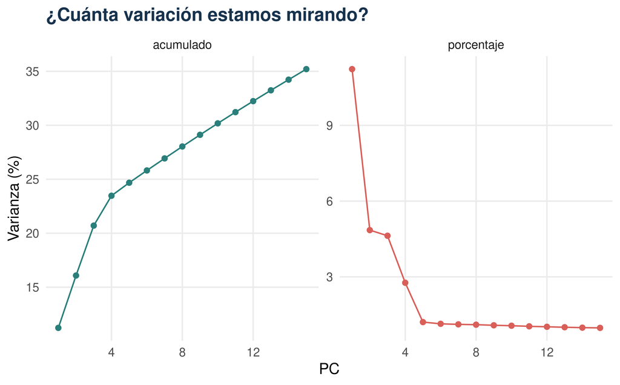

Individual: porcentaje de cada eje. Acumulada: porcentaje de los ejes reunidos.

```r
resumen_pcs |> slice_head(n = 15) |>
  pivot_longer(c(porcentaje, acumulado), names_to = "medida", values_to = "valor") |>
  ggplot(aes(PC, valor, colour = medida)) +
  geom_line() + geom_point() + facet_wrap(~medida, scales = "free_y") +
  scale_colour_manual(values = paleta[1:2]) +
  labs(title = "¿Cuánta variación estamos mirando?", y = "Varianza (%)") +
  guides(colour = "none")
```

**Respondan mirando la tabla:** ¿qué porcentaje explica PC1? ¿Cuánto muestran juntos PC1 y PC2? ¿Qué información podría quedar fuera de ese gráfico?

**Orientación.** PC1 explica 11.2%; PC1–PC2 juntos, 16.1%. El resto queda fuera de esa proyección. Estos porcentajes describen la variación de la expresión, no la precisión para predecir respuesta clínica.

# 5 Actividad 3 — Leer muestras y cambiar el color de la metadata

Los **scores** son las coordenadas de los pacientes. Un punto representa una muestra; muestras cercanas tienen perfiles similares en los componentes mostrados.

```r
scores <- as_tibble(pca$x[, 1:10, drop = FALSE], rownames = "id") |>
  left_join(metadata, by = "id")
head(scores[, c("id", "PC1", "PC2", "lote", "respuesta")])
```

| id | PC1 | PC2 | lote | respuesta |
| --- | --- | --- | --- | --- |
| P001 | -7.435482 | 6.634607 | L1 | Sí |
| P002 | -9.332235 | -2.596477 | L1 | Sí |
| P003 | 7.484957 | -4.834608 | L2 | No |
| P004 | -8.543315 | -3.338411 | L1 | No |
| P005 | 8.017041 | -3.807849 | L2 | No |
| P006 | 8.420399 | -5.007986 | L2 | Sí |

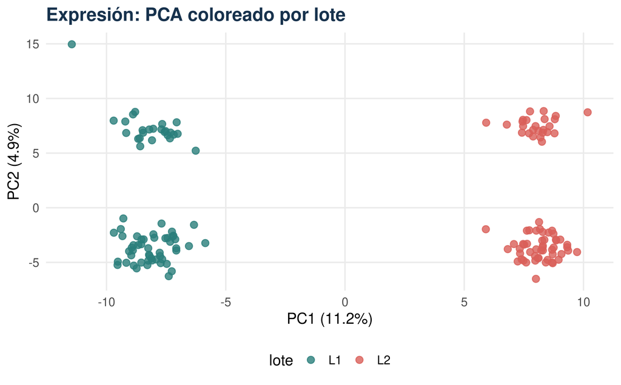

Los componentes se calcularon sin usar lote ni respuesta clínica como etiquetas.

```r
ggplot(scores, aes(PC1, PC2, colour = lote)) +
  geom_point(size = 2.5, alpha = .8) +
  scale_colour_manual(values = paleta[1:2]) +
  labs(title = "Expresión: PCA coloreado por lote",
       x = sprintf("PC1 (%.1f%%)", var_exp[1]),
       y = sprintf("PC2 (%.1f%%)", var_exp[2]))
```

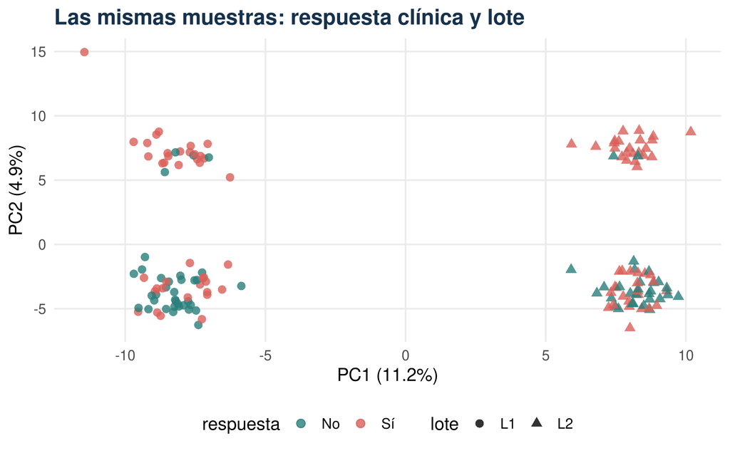

Las posiciones no cambian al colorear por respuesta; sólo cambia la información superpuesta.

```r
ggplot(scores, aes(PC1, PC2, colour = respuesta, shape = lote)) +
  geom_point(size = 2.5, alpha = .8) +
  scale_colour_manual(values = paleta[1:2]) +
  labs(title = "Las mismas muestras: respuesta clínica y lote",
       x = sprintf("PC1 (%.1f%%)", var_exp[1]),
       y = sprintf("PC2 (%.1f%%)", var_exp[2]))
```

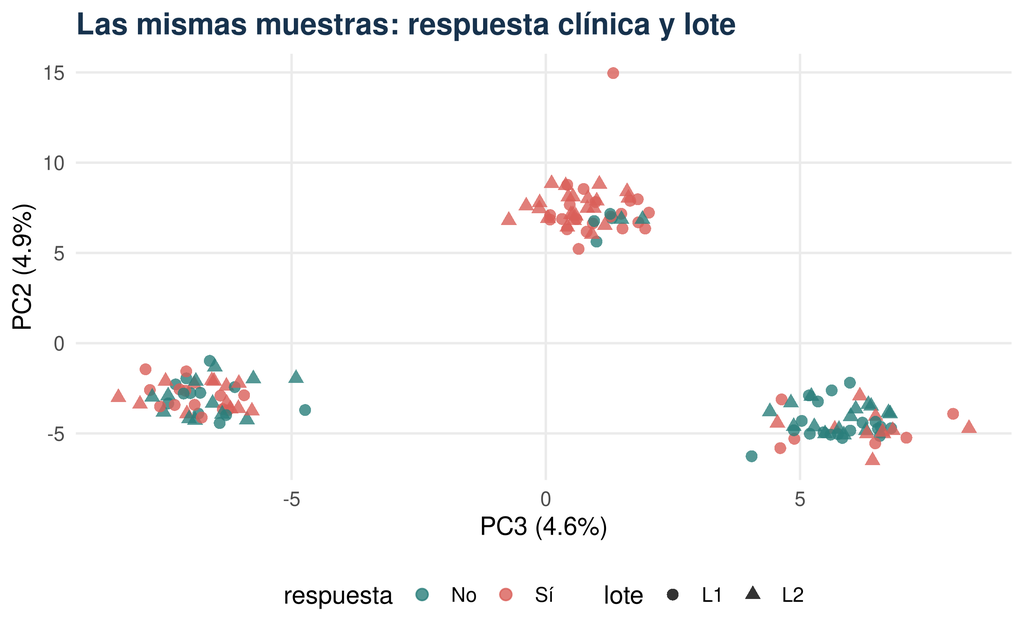

Las posiciones no cambian al colorear por respuesta; sólo cambia la información superpuesta.

```r
#PC2 vs PC3

ggplot(scores, aes(PC3, PC2, colour = respuesta, shape = lote)) +
  geom_point(size = 2.5, alpha = .8) +
  scale_colour_manual(values = paleta[1:2]) +
  labs(title = "Las mismas muestras: respuesta clínica y lote",
       x = sprintf("PC3 (%.1f%%)", var_exp[3]),
       y = sprintf("PC2 (%.1f%%)", var_exp[2]))
```

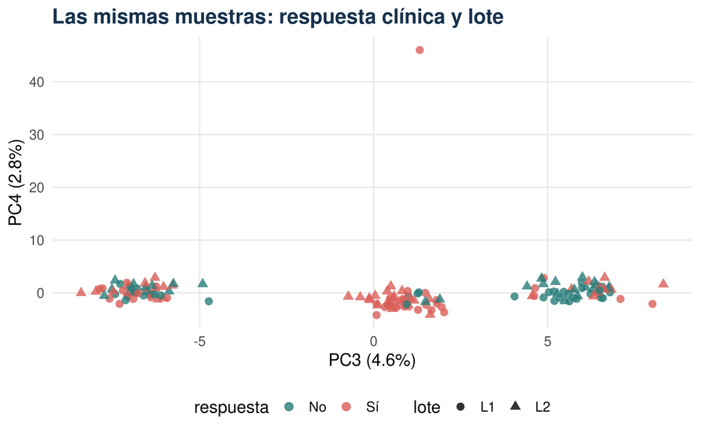

Las posiciones no cambian al colorear por respuesta; sólo cambia la información superpuesta.

```r
ggplot(scores, aes(PC3, PC4, colour = respuesta, shape = lote)) +
  geom_point(size = 2.5, alpha = .8) +
  scale_colour_manual(values = paleta[1:2]) +
  labs(title = "Las mismas muestras: respuesta clínica y lote",
       x = sprintf("PC3 (%.1f%%)", var_exp[3]),
       y = sprintf("PC4 (%.1f%%)", var_exp[4]))
```

**Modifiquen:** reemplacen `colour = respuesta` por `colour = edad` y retiren `scale_colour_manual()` porque edad es continua. Luego hagan un gráfico PC2–PC3, actualizando los porcentajes de los ejes.

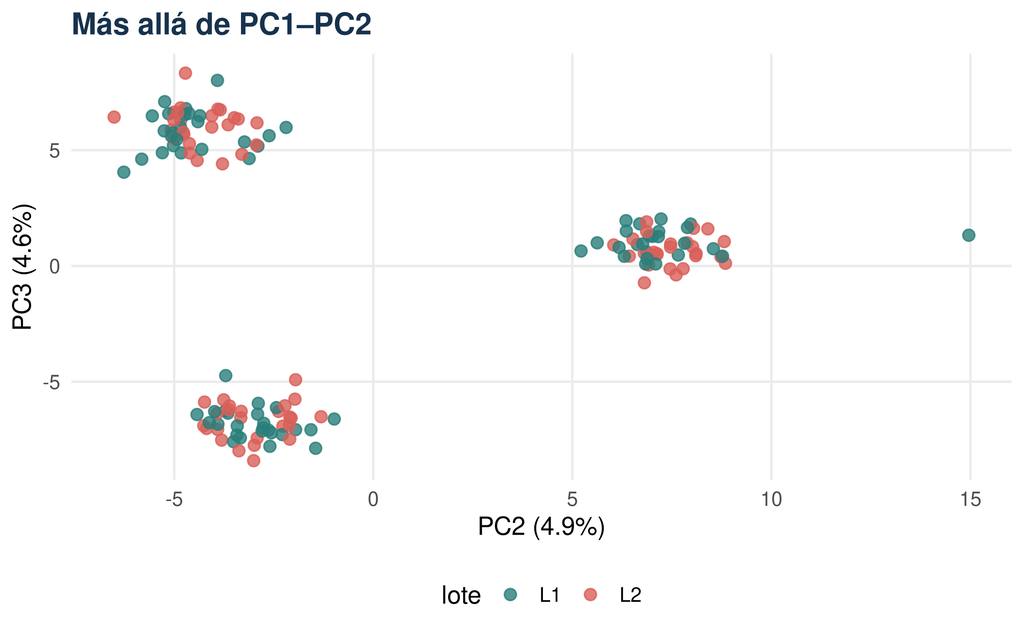

Mirar otro par de componentes puede revelar estructura adicional.

```r
ggplot(scores, aes(PC2, PC3, colour = lote)) +
  geom_point(size = 2.5, alpha = .8) +
  scale_colour_manual(values = paleta[1:2]) +
  labs(title = "Más allá de PC1–PC2",
       x = sprintf("PC2 (%.1f%%)", var_exp[2]),
       y = sprintf("PC3 (%.1f%%)", var_exp[3]))
```

**Escriban dos observaciones y una limitación:** describan por separado lo que ocurre al colorear por lote y por respuesta. Colorear por una etiqueta no hace que PCA haya sido entrenado para reconocerla.

# 6 Actividad 4 — Investigar una muestra atípica

No todas las muestras aisladas son errores. Crucen las métricas de calidad con la posición en varios componentes.

```r
id_revisar <- qc$id[which.max(qc$prop_extremos)]
qc |> filter(id == id_revisar)
```

| id | lote | edad | sexo | respuesta | media | sd | prop_extremos |
| --- | --- | --- | --- | --- | --- | --- | --- |
| P007 | L1 | 46 | Mujer | Sí | 0.7026729 | 1.521348 | 0.12 |

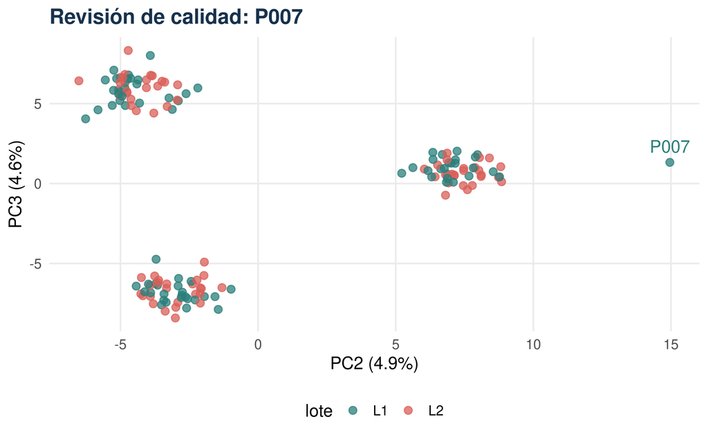

La etiqueta señala la muestra con mayor proporción de valores extremos en el QC.

```r
ggplot(scores, aes(PC2, PC3, colour = lote)) +
  geom_point(size = 2.4, alpha = .75) +
  geom_text(data = filter(scores, id == id_revisar),
            aes(label = id), nudge_y = 1, show.legend = FALSE) +
  scale_colour_manual(values = paleta[1:2]) +
  labs(title = paste("Revisión de calidad:", id_revisar),
       x = sprintf("PC2 (%.1f%%)", var_exp[2]),
       y = sprintf("PC3 (%.1f%%)", var_exp[3]))
```

**Decidan:** ¿qué revisarían en el laboratorio o en los archivos originales? Propongan una razón técnica y una explicación biológica posible. Mantendremos la muestra en el análisis principal y compararemos el resultado al excluirla.

**Orientación.** Revisar identidad, profundidad, preparación y trazabilidad. Una muestra rara puede ser biológicamente válida. En esta simulación P007 contiene un artefacto, pero en un estudio real haría falta evidencia técnica adicional.

# 7 Actividad 5 — Reconocer lote y comparar antes/después

Un lote puede reflejar diferencias de día, placa, operador o kit. Como en Clase 1, un modelo múltiple ayuda a interpretar una asociación ajustando por otras variables.

```r
modelo_pc1 <- lm(PC1 ~ lote + edad + sexo, data = scores)

modelo_pc2 <- lm(PC2 ~ lote + edad + sexo, data = scores)

tidy(modelo_pc1, conf.int = TRUE)
```

| term | estimate | std.error | statistic | p.value | conf.low | conf.high |
| --- | --- | --- | --- | --- | --- | --- |
| (Intercept) | -8.047592901 | 0.383614667 | -20.97832432 | 6.555744e-46 | -8.80574808 | -7.2894377 |
| loteL2 | 16.272464646 | 0.139905098 | 116.31073373 | 7.911661e-146 | 15.99596381 | 16.5489655 |
| edad | -0.001510522 | 0.006433453 | -0.23479178 | 8.146993e-01 | -0.01422525 | 0.0112042 |
| sexoMujer | -0.008764786 | 0.140130901 | -0.06254713 | 9.502127e-01 | -0.28571188 | 0.2681823 |

**Interpreten:** dirección de la asociación lote–PC1 e intervalo de confianza. El coeficiente está en unidades del componente, no en unidades de expresión de un gen. Usamos el modelo para describir el eje; no diagnostica por sí solo su origen.

## 7.1 Comparación con una matriz ajustada

```r
ajustar_lote <- function(X, meta) {
  stopifnot(identical(rownames(X), meta$id))
  corregida <- vapply(seq_len(ncol(X)), function(j) {
    datos_gen <- meta
    datos_gen$expresion <- X[, j]
    modelo <- lm(expresion ~ lote, data = datos_gen)
    if (anyNA(coef(modelo))) stop("Diseño no identificable: revisar confusión.")
    efecto_lote <- predict(modelo, type = "terms")[, "lote"]
    X[, j] - efecto_lote
  }, numeric(nrow(X)))
  dimnames(corregida) <- dimnames(X)
  corregida
}
expr_cor <- ajustar_lote(expr_f, metadata)
pca_cor <- prcomp(expr_cor, center = TRUE, scale. = TRUE)
ve_cor <- 100 * pca_cor$sdev^2 / sum(pca_cor$sdev^2)
scores_cor <- as_tibble(pca_cor$x[, 1:10, drop = FALSE], rownames = "id") |>
  left_join(metadata, by = "id")
```

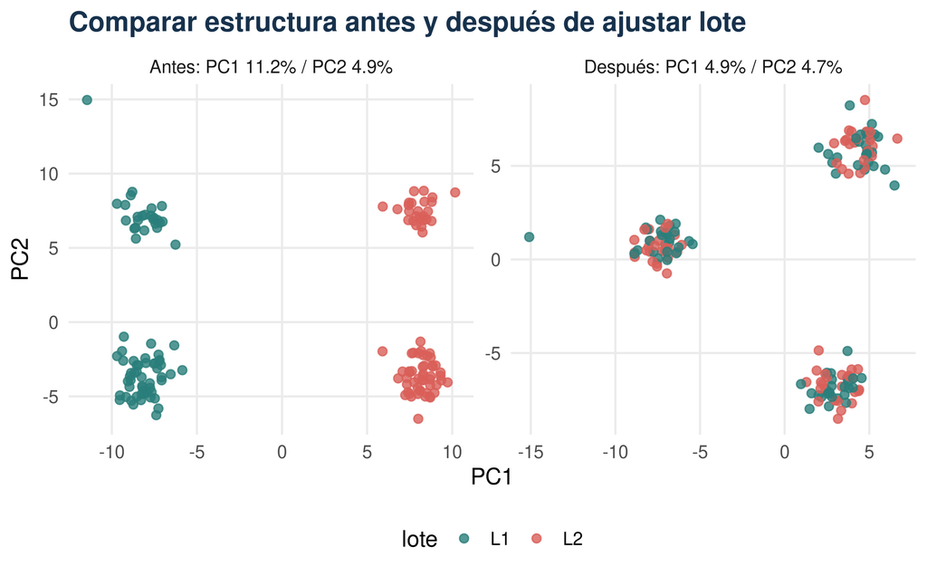

Cada panel muestra un PCA recalculado; sus componentes y porcentajes son distintos.

```r
comparacion <- bind_rows(
  mutate(scores, etapa = sprintf("Antes: PC1 %.1f%% / PC2 %.1f%%", var_exp[1], var_exp[2])),
  mutate(scores_cor, etapa = sprintf("Después: PC1 %.1f%% / PC2 %.1f%%", ve_cor[1], ve_cor[2]))
)
ggplot(comparacion, aes(PC1, PC2, colour = lote)) +
  geom_point(size = 2, alpha = .8) +
  facet_wrap(~etapa, scales = "free") +
  scale_colour_manual(values = paleta[1:2]) +
  labs(title = "Comparar estructura antes y después de ajustar lote")
```

**Respondan:** ¿se mezclan más los lotes? ¿Persisten otros grupos? ¿Qué no podemos concluir sólo porque los lotes se mezclen?

**Orientación.** Menor separación por lote es compatible con el efecto del ajuste en estas muestras. No demuestra que toda la señal restante sea biológica. Si lote y diagnóstico están confundidos, la corrección puede eliminar biología. Aquí el diseño simulado balancea los subtipos entre lotes.

# 8 Actividad 6 — Interpretar los genes asociados a un componente

Los **loadings** son los pesos de los genes en un eje. Revisen los de mayor magnitud y su patrón conjunto. Un loading no es un p-valor, un cambio de expresión entre tratamientos ni una prueba de causalidad.

```r
pc_interes <- "PC1" # Cambiar por PC2 para comparar otro eje.
loadings <- tibble(
  gen = rownames(pca_cor$rotation),
  carga = pca_cor$rotation[, pc_interes]
) |> arrange(desc(abs(carga)))
head(loadings, 12)
```

| gen | carga |
| --- | --- |
| GEN0100 | -0.1441725 |
| GEN0087 | -0.1417884 |
| GEN0085 | -0.1391227 |
| GEN0103 | -0.1369708 |
| GEN0073 | -0.1354375 |
| GEN0089 | -0.1336677 |
| GEN0075 | -0.1334373 |
| GEN0099 | -0.1325283 |
| GEN0093 | -0.1320589 |
| GEN0101 | -0.1317500 |

[output cut: 2 more lines]

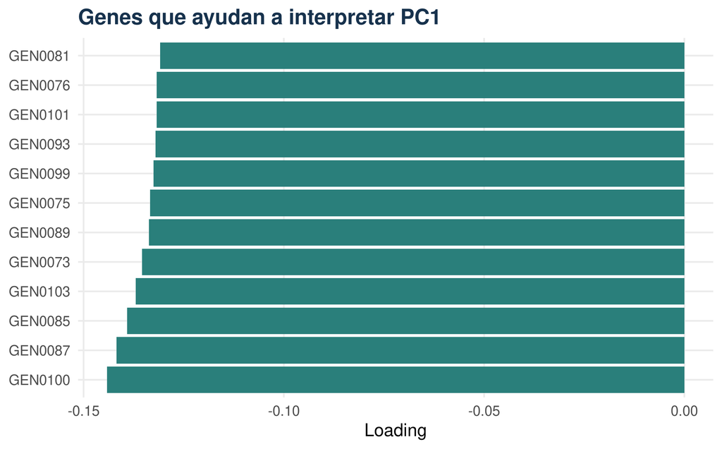

Genes con mayor carga absoluta en el componente seleccionado, después del ajuste.

```r
head(loadings, 12) |>
  ggplot(aes(carga, reorder(gen, carga))) +
  geom_col(fill = paleta[1]) +
  labs(title = paste("Genes que ayudan a interpretar", pc_interes),
       x = "Loading", y = NULL)
```

**Registren:** tres genes destacados, si sus cargas apuntan al mismo lado del eje y qué anotaciones buscarían para interpretar ese conjunto. En un estudio real consultaríamos funciones y vías biológicas; los IDs GEN de estos datos son ficticios y no deben buscarse como genes reales.

**Orientación.** Genes con cargas del mismo signo contribuyen hacia el mismo lado del componente. Invertir todos los signos de un eje no cambia el PCA. Un grupo de genes anotado en un proceso común puede orientar una hipótesis, pero requiere análisis específico y validación.

# 9 Actividad 7 — Agrupar muestras y evaluar la separación

PCA proporciona coordenadas; para asignar grupos utilizaremos k-means y clustering jerárquico. Usamos los primeros 5 componentes, sin escalar de nuevo sus scores. El número de componentes y el número de grupos **son decisiones distintas**.

```r
q <- as.integer(params$n_pcs)
Xcl <- pca_cor$x[, seq_len(q), drop = FALSE]
d <- dist(Xcl)
ks <- 2:7
ajustes_k <- lapply(ks, function(k) {
  set.seed(3300 + k)
  kmeans(Xcl, centers = k, nstart = 50, iter.max = 100)
})
eval_k <- bind_rows(lapply(seq_along(ks), function(j) {
  fit <- ajustes_k[[j]]
  tibble(k = ks[j], WSS = fit$tot.withinss,
         silhouette = mean(cluster::silhouette(fit$cluster, d)[, "sil_width"]),
         menor_cluster = min(fit$size))
}))
eval_k
```

| k | WSS | silhouette | menor_cluster |
| --- | --- | --- | --- |
| 2 | 9296.785 | 0.4020018 | 50 |
| 3 | 5170.874 | 0.5733923 | 50 |
| 4 | 2789.428 | 0.5903507 | 1 |
| 5 | 2416.859 | 0.4987472 | 1 |
| 6 | 2097.525 | 0.3997470 | 1 |
| 7 | 1843.920 | 0.2853772 | 1 |

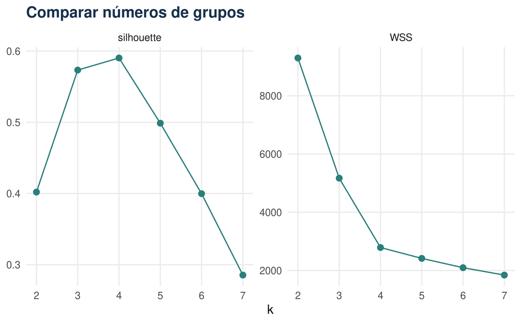

Codo, separación promedio y tamaños de grupo deben leerse juntos.

```r
eval_k |> select(k, WSS, silhouette) |>
  pivot_longer(-k, names_to = "criterio", values_to = "valor") |>
  ggplot(aes(k, valor)) +
  geom_line(colour = paleta[1]) + geom_point(size = 2.5, colour = paleta[1]) +
  facet_wrap(~criterio, scales = "free_y") + scale_x_continuous(breaks = ks) +
  labs(title = "Comparar números de grupos", y = NULL)
```

Silhouette alto indica mejor separación en esta representación; valores próximos a cero indican muestras ambiguas. El codo muestra cuándo la mejora se atenúa.

**Antes de continuar:** elijan un k y justifíquenlo usando silhouette, tamaños y gráfico del codo. No consulten aún el archivo de subtipos. El código siguiente ofrece una regla didáctica reproducible, que pueden contrastar con su elección.

```r
candidatos <- filter(eval_k, menor_cluster >= 5)
if (nrow(candidatos) == 0) stop("Ninguna partición cumple el tamaño mínimo.")
k_elegido <- candidatos$k[which.max(candidatos$silhouette)]
km <- ajustes_k[[match(k_elegido, ks)]]
asignacion <- tibble(id = rownames(Xcl), cluster = factor(km$cluster))
resultado <- left_join(scores_cor, asignacion, by = "id")
table(resultado$cluster)
```

```
##
##  1  2  3
## 50 50 50
```

La regla elige **k = 3**: máximo silhouette entre las opciones con al menos cinco muestras por grupo. No prueba que existan grupos discretos, y este mínimo es una decisión didáctica, no una regla universal.

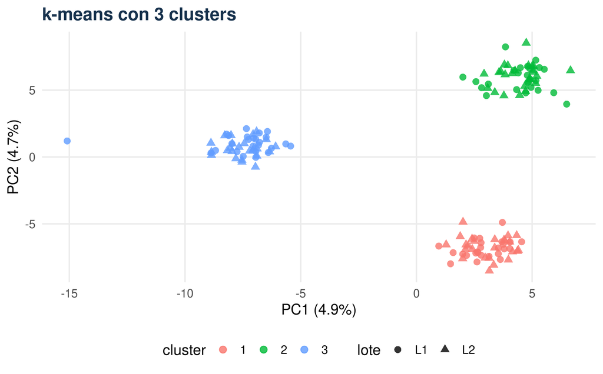

El color representa grupos asignados por k-means; el PCA por sí solo no asignó estas etiquetas.

```r
ggplot(resultado, aes(PC1, PC2, colour = cluster, shape = lote)) +
  geom_point(size = 2.5, alpha = .8) +
  labs(title = paste("k-means con", k_elegido, "clusters"),
       x = sprintf("PC1 (%.1f%%)", ve_cor[1]),
       y = sprintf("PC2 (%.1f%%)", ve_cor[2]))
```

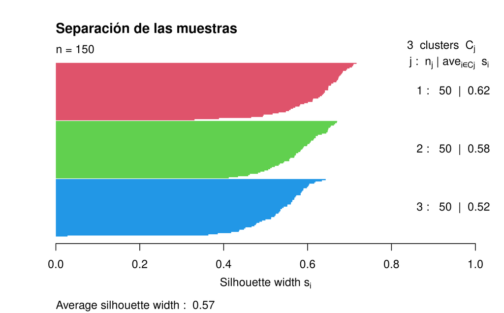

Muestras con silhouette pequeño o negativo requieren revisar su asignación.

```r
sil <- cluster::silhouette(km$cluster, d)
plot(sil, col = seq_len(k_elegido) + 1, border = NA,
     main = "Separación de las muestras")
```

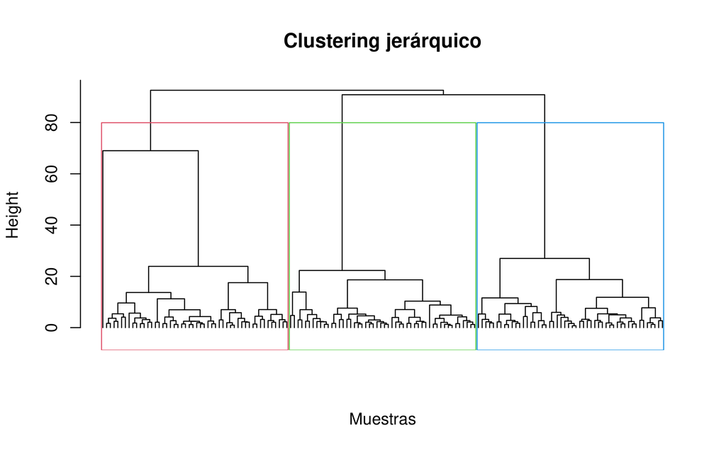

Dendrograma de Ward sobre las mismas coordenadas usadas en k-means.

```r
hc <- hclust(d, method = "ward.D2")
plot(hc, labels = FALSE, hang = -1, main = "Clustering jerárquico",
     xlab = "Muestras", sub = "")
rect.hclust(hc, k = k_elegido, border = seq_len(k_elegido) + 1)
```

```r
table(Ward = cutree(hc, k_elegido), Kmeans = km$cluster)
```

```
##     Kmeans
## Ward  1  2  3
##    1  0  0 50
##    2 50  0  0
##    3  0 50  0
```

**Interpreten la tabla:** ¿los dos métodos agrupan a los mismos pacientes, aunque los números de los clusters cambien?

# 10 Actividad 8 — Conectar perfiles con metadata y candidatos

Después de fijar el análisis, podemos contrastarlo con metadata y con el subtipo que se utilizó para simular. Este último sirve de auditoría; no debe elegirse k buscando forzar su recuperación.

```r
verdad <- read.csv(archivos[3], stringsAsFactors = FALSE)
stopifnot(!anyDuplicated(verdad$id), setequal(verdad$id, resultado$id))
auditoria <- left_join(resultado, verdad, by = "id")
table(Cluster = auditoria$cluster, Subtipo = auditoria$subtipo)
```

```
##        Subtipo
## Cluster  A  B  C
##       1  0 50  0
##       2 50  0  0
##       3  0  0 50
```

```r
table(Cluster = resultado$cluster, Lote = resultado$lote)
```

```
##        Lote
## Cluster L1 L2
##       1 25 25
##       2 25 25
##       3 25 25
```

```r
resultado |>
  group_by(cluster) |>
  summarise(n = n(), edad_media = mean(edad),
            proporcion_respuesta = mean(respuesta == "Sí"), .groups = "drop")
```

| cluster | n | edad_media | proporcion_respuesta |
| --- | --- | --- | --- |
| 1 | 50 | 54.78 | 0.52 |
| 2 | 50 | 56.06 | 0.32 |
| 3 | 50 | 55.92 | 0.88 |

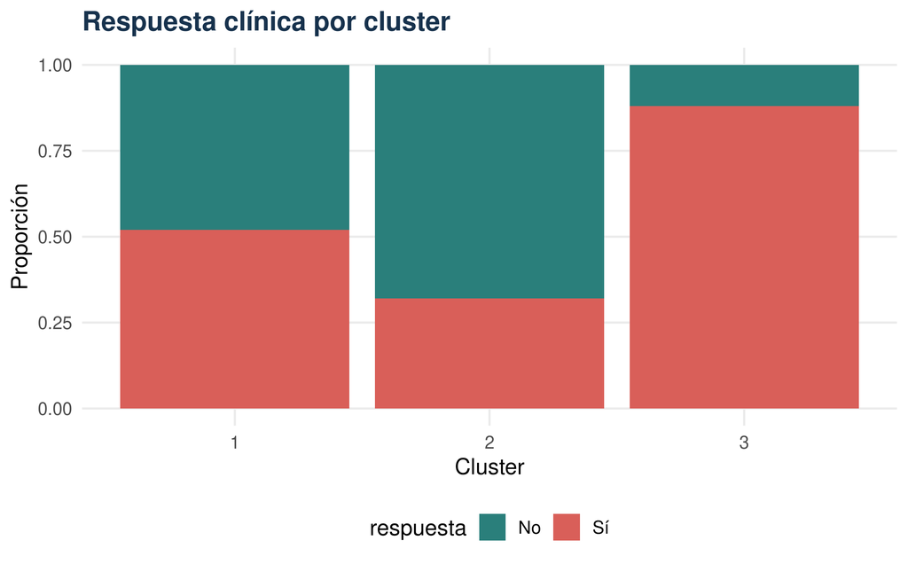

Las proporciones describen asociaciones; no son la precisión de un clasificador.

```r
ggplot(resultado, aes(cluster, fill = respuesta)) +
  geom_bar(position = "fill") +
  scale_fill_manual(values = paleta[1:2]) +
  labs(title = "Respuesta clínica por cluster", x = "Cluster", y = "Proporción")
```

## 10.1 Genes que caracterizan un grupo

Compararemos descriptivamente un grupo con el resto. Estos genes participaron en construir los clusters: no usaremos p-valores ni FDR como confirmación de esas diferencias seleccionadas.

```r
cluster_obj <- names(which.max(table(resultado$cluster)))
meta_genes <- resultado[match(rownames(expr_cor), resultado$id), ]
stopifnot(identical(meta_genes$id, rownames(expr_cor)))
en_obj <- meta_genes$cluster == cluster_obj
diferencia <- colMeans(expr_cor[en_obj, , drop = FALSE]) -
  colMeans(expr_cor[!en_obj, , drop = FALSE])
marcadores <- tibble(
  gen = colnames(expr_cor),
  diferencia = as.numeric(diferencia),
  diferencia_en_DE = as.numeric(diferencia / apply(expr_cor, 2, sd))
) |> arrange(desc(abs(diferencia_en_DE)))
head(marcadores, 12)
```

| gen | diferencia | diferencia_en_DE |
| --- | --- | --- |
| GEN0064 | 1.843879 | 1.643327 |
| GEN0045 | 1.561258 | 1.595437 |
| GEN0057 | 1.617455 | 1.571789 |
| GEN0065 | 1.538851 | 1.569960 |
| GEN0048 | 1.568793 | 1.568085 |
| GEN0042 | 1.575466 | 1.557876 |
| GEN0043 | 1.641258 | 1.555055 |
| GEN0070 | 1.612431 | 1.536384 |
| GEN0049 | 1.707015 | 1.520823 |
| GEN0068 | 1.511399 | 1.518254 |

[output cut: 2 more lines]

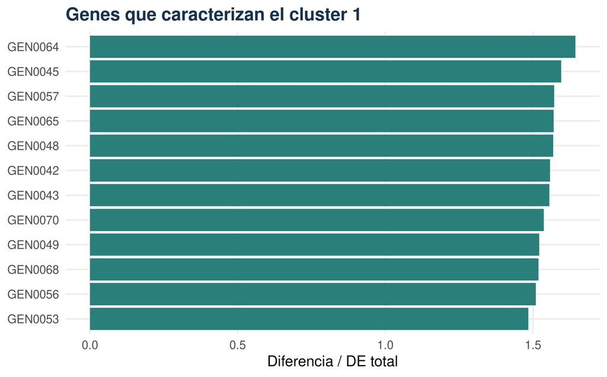

Ranking descriptivo de candidatos: diferencia dividida por la DE total del gen.

```r
head(marcadores, 12) |>
  ggplot(aes(diferencia_en_DE, reorder(gen, diferencia_en_DE))) +
  geom_col(fill = paleta[1]) +
  labs(title = paste("Genes que caracterizan el cluster", cluster_obj),
       x = "Diferencia / DE total", y = NULL)
```

**Redacten:** un hallazgo sobre respuesta, uno sobre lote y tres candidatos que seguirían estudiando. Expliquen qué datos nuevos harían falta para hablar de biomarcadores clínicamente útiles.

# 11 Actividad 9 — Comprobar si la interpretación se mantiene

## 11.1 Otra elección de escalamiento

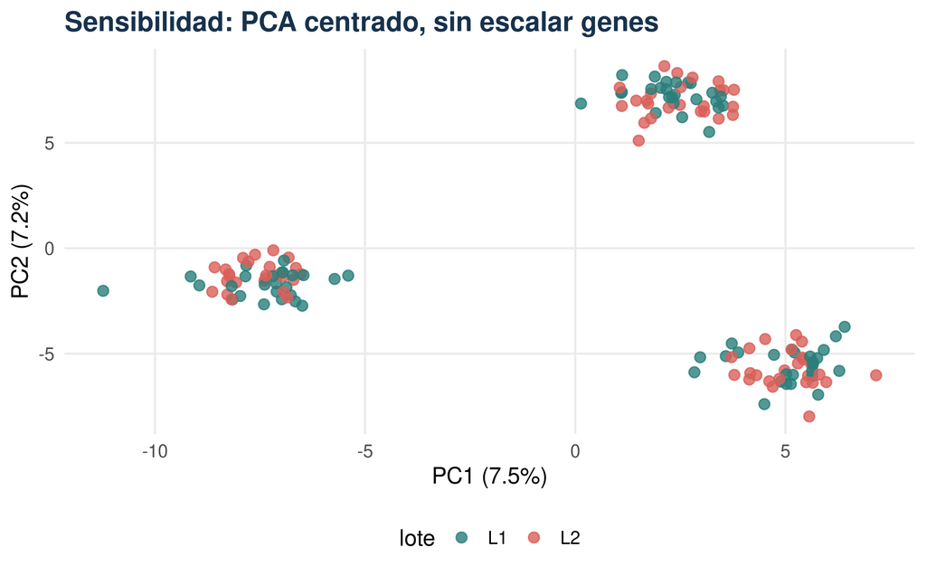

El gráfico debe interpretarse junto con la elección de preprocesamiento.

```r
pca_sin_escalar <- prcomp(expr_cor, center = TRUE, scale. = FALSE)
ve_sin <- 100 * pca_sin_escalar$sdev^2 / sum(pca_sin_escalar$sdev^2)
scores_sin <- as_tibble(pca_sin_escalar$x[, 1:2], rownames = "id") |>
  left_join(metadata, by = "id")
ggplot(scores_sin, aes(PC1, PC2, colour = lote)) +
  geom_point(size = 2.5, alpha = .8) +
  scale_colour_manual(values = paleta[1:2]) +
  labs(title = "Sensibilidad: PCA centrado, sin escalar genes",
       x = sprintf("PC1 (%.1f%%)", ve_sin[1]),
       y = sprintf("PC2 (%.1f%%)", ve_sin[2]))
```

**Comparen** con el PCA ajustado y escalado. En esta matriz todas las mediciones tienen unidades comparables; en un panel con glucosa, peso y presión arterial, las diferencias de escala pueden tener mucha mayor influencia.

## 11.2 Repetir el análisis sin la muestra bajo revisión

```r
mantener <- rownames(expr_f) != id_revisar
expr_sens <- ajustar_lote(expr_f[mantener, , drop = FALSE], metadata[mantener, ])
pca_sens <- prcomp(expr_sens, center = TRUE, scale. = TRUE)
ve_sens <- 100 * pca_sens$sdev^2 / sum(pca_sens$sdev^2)
set.seed(3401)
km_sens <- kmeans(pca_sens$x[, seq_len(q), drop = FALSE],
                  centers = k_elegido, nstart = 50, iter.max = 100)
sensibilidad <- as_tibble(pca_sens$x[, 1:2], rownames = "id") |>
  mutate(cluster_nuevo = factor(km_sens$cluster)) |>
  left_join(asignacion, by = "id")
table(Principal = sensibilidad$cluster, Sin_muestra = sensibilidad$cluster_nuevo)
```

```
##          Sin_muestra
## Principal  1  2  3
##         1  0  0 50
##         2  0 50  0
##         3 49  0  0
```

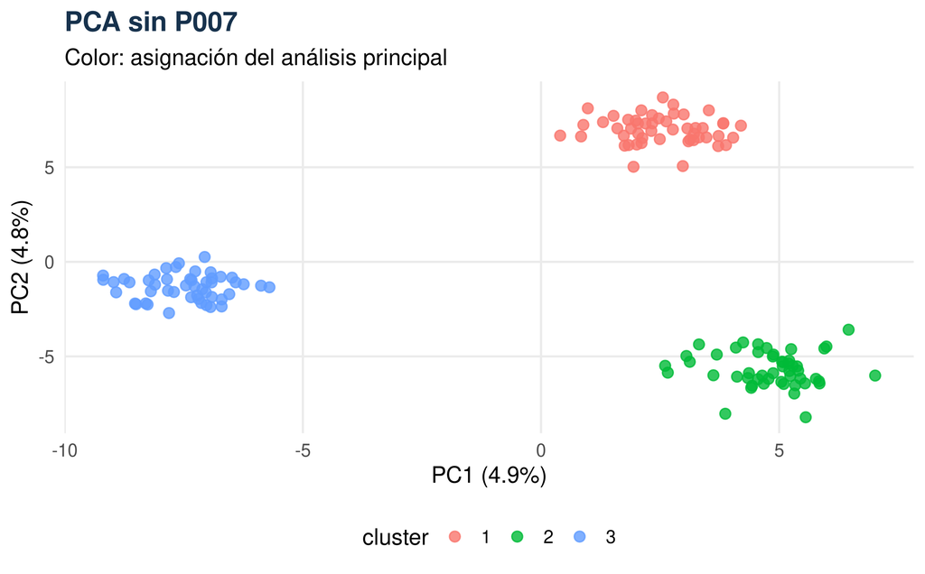

Sensibilidad a la muestra bajo revisión: se recalculan ajuste, PCA y agrupación.

```r
ggplot(sensibilidad, aes(PC1, PC2, colour = cluster)) +
  geom_point(size = 2.5, alpha = .8) +
  labs(title = paste("PCA sin", id_revisar),
       subtitle = "Color: asignación del análisis principal",
       x = sprintf("PC1 (%.1f%%)", ve_sens[1]),
       y = sprintf("PC2 (%.1f%%)", ve_sens[2]))
```

Los ejes pueden cambiar de orientación o de orden entre análisis. Comparen relaciones entre pacientes y la tabla de asignaciones, no sólo izquierda/derecha. Aquí mantenemos k para comparar grupos: no evaluamos si la elección de k es estable.

**Práctica adicional:** rendericen con `params = list(n_pcs = 3)` y comparen con cinco PCs. Registren si cambia k y si cambian las conclusiones clínicas.

**Orientación.** Si las mismas muestras continúan juntas, hay estabilidad frente a esa decisión concreta. La simulación tiene señal fuerte y puede ser muy estable; los datos reales no tienen por qué comportarse así. Una réplica externa sigue siendo necesaria para evaluar utilidad clínica.

# 12 Informe final

Entreguen un informe breve con estos resultados:

| Evidencia | Interpretación que debe acompañarla |
| --- | --- |
| Scree plot | Porcentaje mostrado y variación que queda fuera |
| PCA por lote y respuesta | Dos observaciones, una explicación posible y una limitación |
| PC2–PC3 y QC | Muestra a revisar y acción propuesta |
| Antes/después del ajuste | Qué patrón cambia y qué no puede concluirse |
| Loadings | Genes destacados y anotación biológica que buscarían |
| Clusters y silhouette | k elegido, tamaños y muestras ambiguas |
| Metadata y candidatos | Hallazgo descriptivo y plan de validación |
| Sensibilidad | Qué conclusiones se mantienen al cambiar decisiones |

Formato sugerido: **“Observamos ____. Podría relacionarse con ____. Lo comprobamos mediante ____. Estos datos no permiten concluir ____.”**

Las funciones se documentan en [`prcomp`](https://stat.ethz.ch/R-manual/R-devel/library/stats/html/prcomp.html) y [silhouette](https://stat.ethz.ch/R-manual/R-devel/library/cluster/html/silhouette.html). Para RNA-seq real, consultar la [guía de DESeq2](https://bioconductor.org/packages/release/bioc/vignettes/DESeq2/inst/doc/DESeq2.html) sobre transformación y exploración de muestras; este ejercicio no sustituye el preprocesamiento específico de esa plataforma.